# Mission Compostable Image Processing Engine

```python
from skimage import io, filters, color
from skimage.color import rgb2gray
import os

import numpy as np
from scipy import stats

import matplotlib.pyplot as plt
from mpl_toolkits import mplot3d
from mpl_toolkits.mplot3d import Axes3D

from collections import deque
```

```python
plt.rcParams['figure.figsize'] = (20.0, 10.0)
```

Read image from file & convert to grayscale.

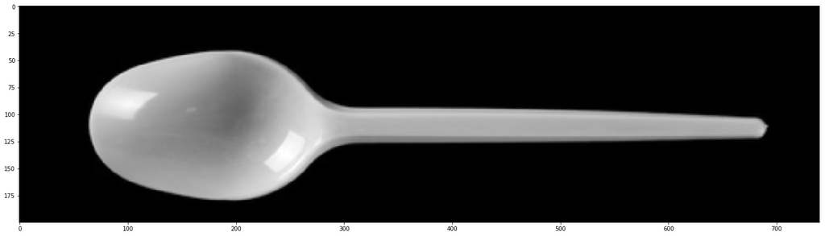

```python
image = io.imread('../images/plastic_spoons/sp5.png')
grayscale = rgb2gray(image)
io.imshow(grayscale)
```

Here's a 3D contour plot of the greyscale image's pixel values. The spoon is much lighter than its background, so it's possible to determine its edge and mask the rest of the image.

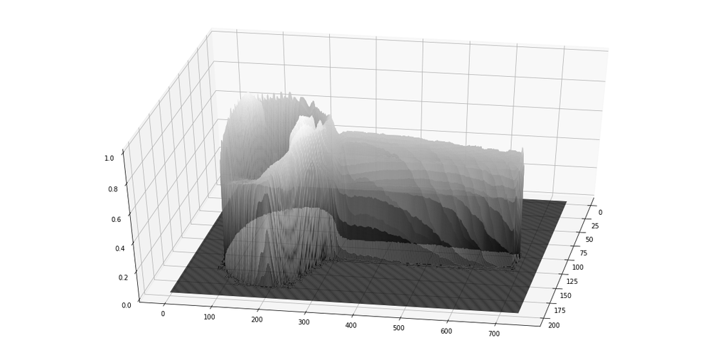

```python
xx, yy = np.mgrid[0:grayscale.shape[0], 0:grayscale.shape[1]]

fig = plt.figure()
ax = fig.gca(projection='3d')
ax.plot_surface(xx, yy, grayscale ,rstride=1, cstride=1, cmap=plt.cm.gray,
        linewidth=0)

ax.view_init(elev=40., azim=10)
plt.show()
```

## Find the Lightest Area in the Image

Specifically, find the average value of the lightest area of the image that is at least `area_size` pixels.

```python
# The threshold determines how close to the maximum pixel value the "light" areas should be
threshold = 0.01
pixel_count = 0
```

Determine the maximum pixel value in the image.

```python
max_value = 0
for y, y_val in enumerate(grayscale):
    for x, x_val in enumerate(y_val):
        if x_val > max_value:
            max_value = x_val
```

Iterate over the image, applying a filter to all pixels with a value less than `max_value - threshold`. Then, pick one pixel in the filtered image and perform BFS, counting each of its adjacent pixels in the process. If the light area is larger than `area_size`, we're done! If it's too small, increase the `threshold` by 0.001 and repeat until a large enough area is found.

```python
while pixel_count < area_size:
    filtered = np.zeros(grayscale.shape, dtype=np.int8)
    count = 0
    for y, y_val in enumerate(grayscale):
        for x, x_val in enumerate(y_val):
            if x_val > max_value - threshold:
                count += 1
                filtered[y,x] = 1

    # Select a pixel in the filtered image to start with
    for y, y_val in enumerate(filtered):
        for x, x_val in enumerate(y_val):
            if x_val == 1:
                # Perform BFS on this pixel
                start = (y, x)
                visited = np.zeros(grayscale.shape, dtype=np.int8)
                search_queue = deque()
                search_queue.append(start)
                visited[start] = 1
                pixel_count = 1

                while search_queue:
                    popped = search_queue.popleft()
                    up = (popped[0] + 1, popped[1])
                    down = (popped[0] - 1, popped[1])
                    left = (popped[0], popped[1] - 1)
                    right = (popped[0], popped[1] + 1)
                    for neighbor in [up, down, left, right]:
                        if filtered[neighbor] == 1 and visited[neighbor] == 0:
                            pixel_count += 1
                            visited[neighbor] = 1
                            search_queue.append(neighbor)
                            filtered[neighbor] = 0
                if pixel_count >= area_size:
                    break
        if pixel_count >= area_size:
            break

    # If we haven't found a large enough light area, increase the threshold and repeat the process.
    threshold += 0.001
```

Now, determine the average pixel value of the pixels in the light area.

```python
value_sum = 0
value_count = 0
for y, y_val in enumerate(grayscale):
    for x, x_val in enumerate(y_val):
        if visited[y][x] == 1:
            value_count += 1
            value_sum += grayscale[y][x]
average_value = value_sum/value_count
average_value
```

```
0.9962113659022939
```

## Edge Detection & Masking

Determine the edges of the spoon and mask all pixels outside that area.

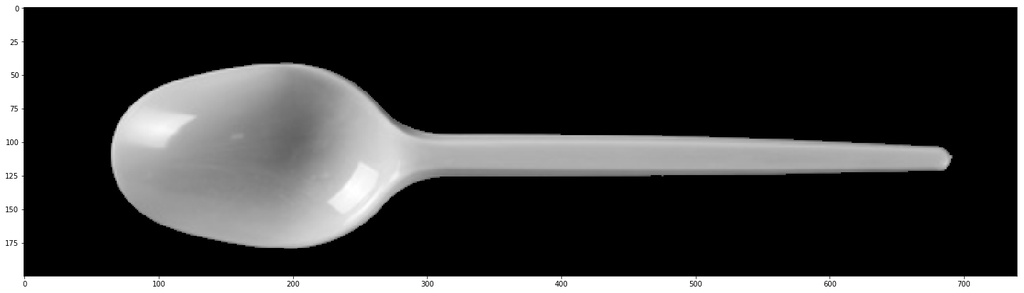

```python
blur = filters.gaussian(grayscale, sigma=np.std(grayscale), multichannel=False)
t = filters.threshold_otsu(blur)
mask = blur > t
masked = np.zeros_like(image)
masked[mask] = image[mask]
io.imshow(masked)
```

Iterate over the rows of the masked image, generating statistics on the pixel values in the image.

```python
rows,cols = masked.shape[0:2]

listy = []
for x in range (1,rows):
    for y in range (1,cols):
        pixel = grayscale[x,y]
        if pixel > 0.0:
            listy.append(pixel)

count = len(listy); print("Count: ", count)
mean = np.mean(listy); print("Mean: ", mean)
median = np.median(listy); print("Median: ", median)
mode = stats.mode(listy); print("Mode: ", mode)

maximum = np.max(listy)
```

```
Count:  35735
Mean:  0.6557633121808958
Median:  0.6705882352941176
Mode:  ModeResult(mode=array([0.68235294]), count=array([1108]))
```

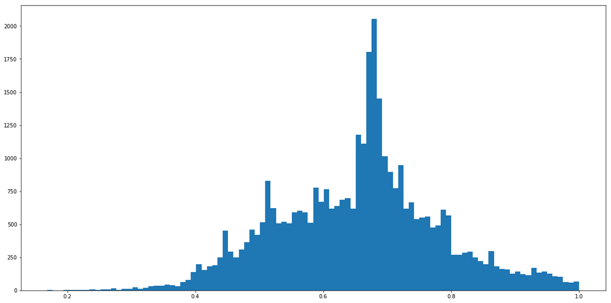

```python
plt.hist(listy, 100)
plt.show()
```

Determine the difference between the lightest area's average pixel value, and the average pixel value for the whole spoon. Scale by the image's maximum pixel value.

```python
(average_value - mean)/maximum
```

```
0.3404480537213981
```

It's above 0.2, so it's probably plastic!